# HCDS - Clase 6

#### Previo

Para comenzar a trabajar, cargamos la librería `tidyverse` y la base a utilizar, esta última la guardaremos en un objeto que llamamos `viv`, con el siguiente código:

```r
library(tidyverse)

viv <- read_csv("viviendas.csv")
```

### Actividad I

Reporte un análisis descrptivo de los datos de las viviendas:

1. Reporte un resumen descriptivo de tosas las variables en el conjunto de datos. Interprete sus resultados

```r
str(viv)
```

```
## tibble [20,640 × 10] (S3: spec_tbl_df/tbl_df/tbl/data.frame)
##  $ longitud      : num [1:20640] -122 -122 -122 -122 -122 ...
##  $ latitud       : num [1:20640] 37.9 37.9 37.9 37.9 37.9 ...
##  $ edad_prom_viv : num [1:20640] 41 21 52 52 52 52 52 NA 42 52 ...
##  $ total_hab     : num [1:20640] 880 7099 1467 1274 1627 ...
##  $ total_dorm    : num [1:20640] 129 1106 190 235 280 ...
##  $ npoblacion    : num [1:20640] 322 2401 496 558 565 ...
##  $ nhogares      : num [1:20640] 126 1138 177 219 259 ...
##  $ ingreso_prom  : num [1:20640] 8.33 8.3 7.26 5.64 3.85 ...
##  $ valor_prom_viv: num [1:20640] 452600 358500 352100 341300 342200 ...
##  $ prox_oceano   : chr [1:20640] "NEAR BAY" "NEAR BAY" "NEAR BAY" "NEAR BAY" ...
##  - attr(*, "spec")=
##   .. cols(
##   ..   longitud = col_double(),
##   ..   latitud = col_double(),
##   ..   edad_prom_viv = col_double(),
##   ..   total_hab = col_double(),
##   ..   total_dorm = col_double(),
##   ..   npoblacion = col_double(),
##   ..   nhogares = col_double(),
##   ..   ingreso_prom = col_double(),
##   ..   valor_prom_viv = col_double(),
##   ..   prox_oceano = col_character()
##   .. )
```

```r
names(viv)
```

```
##  [1] "longitud"       "latitud"        "edad_prom_viv"  "total_hab"
##  [5] "total_dorm"     "npoblacion"     "nhogares"       "ingreso_prom"
##  [9] "valor_prom_viv" "prox_oceano"
```

```r
summary(viv)
```

```
##     longitud         latitud      edad_prom_viv     total_hab
##  Min.   :-124.3   Min.   :32.54   Min.   : 1.00   Min.   :    2
##  1st Qu.:-121.8   1st Qu.:33.93   1st Qu.:18.00   1st Qu.: 1448
##  Median :-118.5   Median :34.26   Median :29.00   Median : 2127
##  Mean   :-119.6   Mean   :35.63   Mean   :28.63   Mean   : 2636
##  3rd Qu.:-118.0   3rd Qu.:37.71   3rd Qu.:37.00   3rd Qu.: 3148
##  Max.   :-114.3   Max.   :41.95   Max.   :52.00   Max.   :39320
##                                   NA's   :10
##    total_dorm       npoblacion       nhogares       ingreso_prom
##  Min.   :   1.0   Min.   :    3   Min.   :   1.0   Min.   : 0.4999
##  1st Qu.: 296.0   1st Qu.:  787   1st Qu.: 280.0   1st Qu.: 2.5634
##  Median : 435.0   Median : 1166   Median : 409.0   Median : 3.5348
##  Mean   : 537.9   Mean   : 1425   Mean   : 499.5   Mean   : 3.8707
##  3rd Qu.: 647.0   3rd Qu.: 1725   3rd Qu.: 605.0   3rd Qu.: 4.7432
##  Max.   :6445.0   Max.   :35682   Max.   :6082.0   Max.   :15.0001
##  NA's   :209
##  valor_prom_viv   prox_oceano
##  Min.   : 14999   Length:20640
##  1st Qu.:119600   Class :character
##  Median :179700   Mode  :character
##  Mean   :206856
##  3rd Qu.:264725
##  Max.   :500001
##
```

2. Construya una tabla que indique la cantidad de missing en cada variable. Revise si hay mayor cantidad de missing en algún tipo de vivienda

```r
n_miss <- viv %>%       #Desde la base viv preguntamos cuáles obsvaciones
          is.na() %>%   # son NA, esto nos entrega una matriz con TRUE y FALSE
          colSums()     # al sumar tenemos TRUE=1, FALSE=0, entonces sumamos por
```

Desde la base `viv` preguntamos a toda la base cuáles elementos son NA, esto nos entrega una matriz de las mismas dimensiones de la base sólo con TRUE y FALSE, luego para obtener la cantidad de TRUE de cada variable se suma por columnas, dado que cada TRUE cuenta como un 1 y cada FALSE cuenta como 0.

Guardamos lo anterior en un data frame:

```r
t_nmiss <- data.frame(n_miss) # Guardamos lo anterior en un data.frame
t_nmiss
```

```
##                n_miss
## longitud            0
## latitud             0
## edad_prom_viv      10
## total_hab           0
## total_dorm        209
## npoblacion          0
## nhogares            0
## ingreso_prom        0
## valor_prom_viv      0
## prox_oceano         0
```

#### Extra

Como contenido adicional, introduciremos la librería `VIM`, la cual es muy útil para el manejo de valores faltantes:

```r
library(VIM)
```

Primero generamos un gráfico agregado:

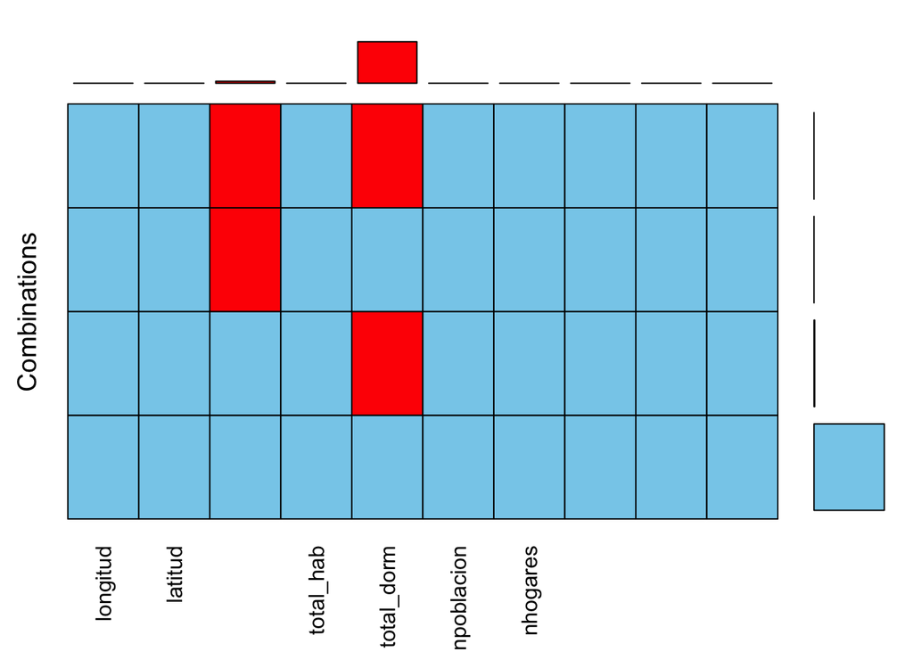

```r
plot_missing <-  viv %>%
  aggr(combined= TRUE, numbers = TRUE)
```

```r
plot_missing
```

```
##
##  Missings in variables:
##       Variable Count
##  edad_prom_viv    10
##     total_dorm   209
```

```r
summary(plot_missing)
```

```
##
##  Missings per variable:
##        Variable Count
##        longitud     0
##         latitud     0
##   edad_prom_viv    10
##       total_hab     0
##      total_dorm   209
##      npoblacion     0
##        nhogares     0
##    ingreso_prom     0
##  valor_prom_viv     0
##     prox_oceano     0
##
##  Missings in combinations of variables:
##         Combinations Count      Percent
##  0:0:0:0:0:0:0:0:0:0 20423 98.948643411
##  0:0:0:0:1:0:0:0:0:0   207  1.002906977
##  0:0:1:0:0:0:0:0:0:0     8  0.038759690
##  0:0:1:0:1:0:0:0:0:0     2  0.009689922
```

- El 1% solo tiene missing en la variable 5,
- El 0.03% tiene missing en la variable 3,
- y el 0.009% tiene missing en la 3 y en la 5.

Veamos si hay sesgo en los valores faltantes:

```r
viv %>%
  group_by(prox_oceano) %>%
  summarise(num_miss = sum(is.na(total_dorm)), ntot = n()
            , prop = num_miss/ntot*100)
```

```
## # A tibble: 5 x 4
##   prox_oceano num_miss  ntot  prop
##   <chr>          <int> <int> <dbl>
## 1 <1H OCEAN        102  9136 1.12
## 2 INLAND            55  6551 0.840
## 3 ISLAND             0     5 0
## 4 NEAR BAY          22  2290 0.961
## 5 NEAR OCEAN        30  2658 1.13
```

Se observa mayor cantidad de missing en viviendas cercanas al oceano.

Lo anterior puede verse de otras maneras, donde podemos ver que no tenemos sesgo significativo.

```r
table(is.na(viv$total_dorm),viv$prox_oceano)
```

```
##
##         <1H OCEAN INLAND ISLAND NEAR BAY NEAR OCEAN
##   FALSE      9034   6496      5     2268       2628
##   TRUE        102     55      0       22         30
```

```r
round(prop.table(table(is.na(viv$total_dorm), viv$prox_oceano),2)*100,1)
```

```
##
##         <1H OCEAN INLAND ISLAND NEAR BAY NEAR OCEAN
##   FALSE      98.9   99.2  100.0     99.0       98.9
##   TRUE        1.1    0.8    0.0      1.0        1.1
```

Realice un gráfico que permita observar la distribución de la edad promedio de la vivienda

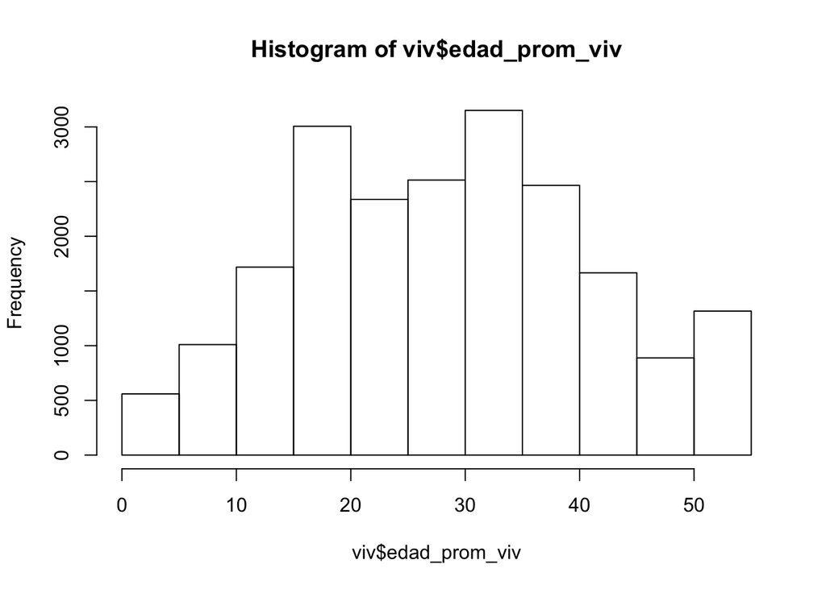

```r
hist(viv$edad_prom_viv)
```

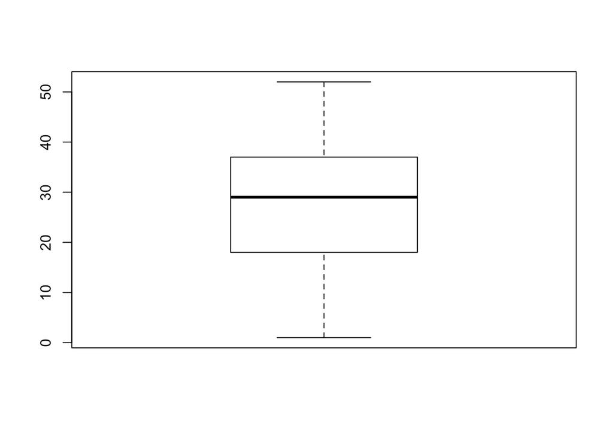

```r
boxplot(viv$edad_prom_viv)
```

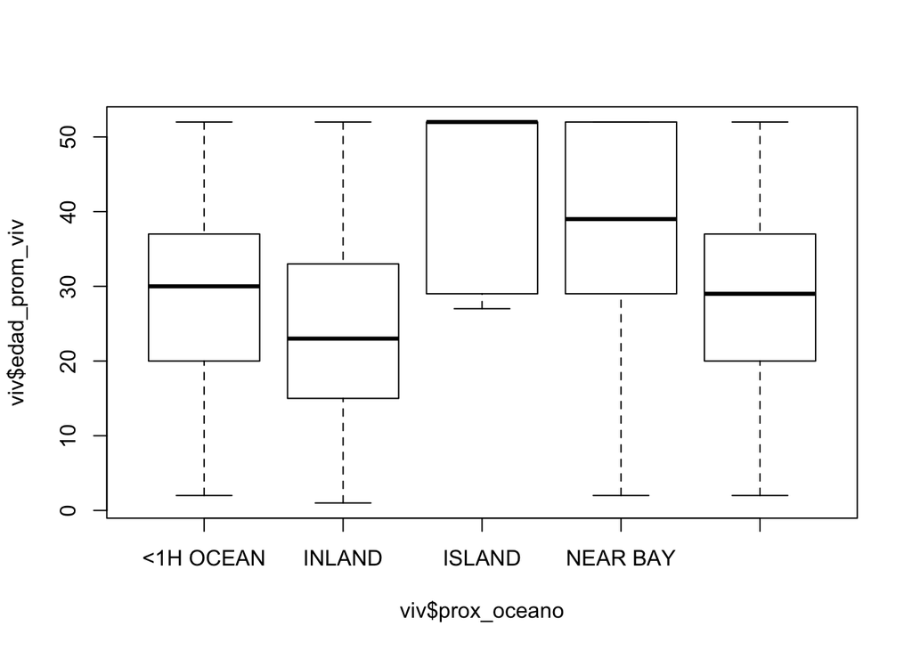

```r
boxplot(viv$edad_prom_viv~viv$prox_oceano)
```

Construya una tabla que entregue el promedio del precio de la vivienda por tramo de antigüedad Puede usar la función **cut()**

```r
names(viv)
```

```
##  [1] "longitud"       "latitud"        "edad_prom_viv"  "total_hab"
##  [5] "total_dorm"     "npoblacion"     "nhogares"       "ingreso_prom"
##  [9] "valor_prom_viv" "prox_oceano"
```

```r
viv$tramo_edad <- cut(viv$edad_prom_viv, breaks = c(0,10,20,30,40,50,60))
# Generamos los tramos

table(viv$tramo_edad)
```

```
##
##  (0,10] (10,20] (20,30] (30,40] (40,50] (50,60]
##    1569    4724    4851    5616    2554    1316
```

```r
# Ahora obtenemos los estadísticos de resumen.
pv<-viv %>%
  group_by(tramo_edad) %>%
  summarise(n = n(),
            prom = mean(valor_prom_viv),
            sd = sd(valor_prom_viv),
            q1 = quantile(valor_prom_viv,0.25),
            q2 = quantile(valor_prom_viv,0.5),
            q3 = quantile(valor_prom_viv,0.75),
            max = max(valor_prom_viv))
pv
```

```
## # A tibble: 7 x 8
##   tramo_edad     n    prom      sd     q1     q2     q3    max
##   <fct>      <int>   <dbl>   <dbl>  <dbl>  <dbl>  <dbl>  <dbl>
## 1 (0,10]      1569 200263. 103071. 128300 170400 249100 500001
## 2 (10,20]     4724 191182. 101837. 114675 166100 247125 500001
## 3 (20,30]     4851 206793. 115022. 116800 184800 266250 500001
## 4 (30,40]     5616 206684. 116512. 121400 180000 256300 500001
## 5 (40,50]     2554 205910. 118715. 114325 171550 267625 500001
## 6 (50,60]     1316 274107. 139278. 157650 258300 380075 500001
## 7 <NA>          10 163770  111722.  76950 128200 245525 375000
```

```r
colSums(pv[,2])
```

```
##     n
## 20640
```

Realice un análisis de las correlaciones entre las variables

Como estamos calculando la correlación de Pearson, necesitamos sólo considerar las variables numéricas, por lo que eliminamoslas ultimas dos columnas de la matriz para poder calcularlos, en este caso, las columnas en la posición 10 y 11

```r
library(corrplot)
viv_cont = na.omit(viv[, -c(10,11)])
```

Calculamos la correlación de estas variables y su correlograma usando la librería `corrplot`

```r
cor_viv = cor(viv_cont)
cor_viv
```

```
##                   longitud     latitud edad_prom_viv   total_hab   total_dorm
## longitud        1.00000000 -0.92460856   -0.10861082  0.04516914  0.069296048
## latitud        -0.92460856  1.00000000    0.01110446 -0.03633324 -0.066658379
## edad_prom_viv  -0.10861082  0.01110446    1.00000000 -0.36050429 -0.320303772
## total_hab       0.04516914 -0.03633324   -0.36050429  1.00000000  0.930367861
## total_dorm      0.06929605 -0.06665838   -0.32030377  0.93036786  1.000000000
## npoblacion      0.09991441 -0.10864061   -0.29552925  0.85725526  0.877726640
## nhogares        0.05618341 -0.07143801   -0.30260182  0.91897672  0.979725873
## ingreso_prom   -0.01587939 -0.07931502   -0.11789596  0.19776731 -0.007869355
## valor_prom_viv -0.04565267 -0.14442203    0.10677992  0.13320302  0.049592151
##                  npoblacion    nhogares ingreso_prom valor_prom_viv
## longitud        0.099914413  0.05618341 -0.015879390    -0.04565267
## latitud        -0.108640614 -0.07143801 -0.079315022    -0.14442203
## edad_prom_viv  -0.295529248 -0.30260182 -0.117895963     0.10677992
## total_hab       0.857255262  0.91897672  0.197767310     0.13320302
## total_dorm      0.877726640  0.97972587 -0.007869355     0.04959215
## npoblacion      1.000000000  0.90717255  0.004893279    -0.02543977
## nhogares        0.907172545  1.00000000  0.013267830     0.06478050
## ingreso_prom    0.004893279  0.01326783  1.000000000     0.68829625
## valor_prom_viv -0.025439774  0.06478050  0.688296247     1.00000000
```

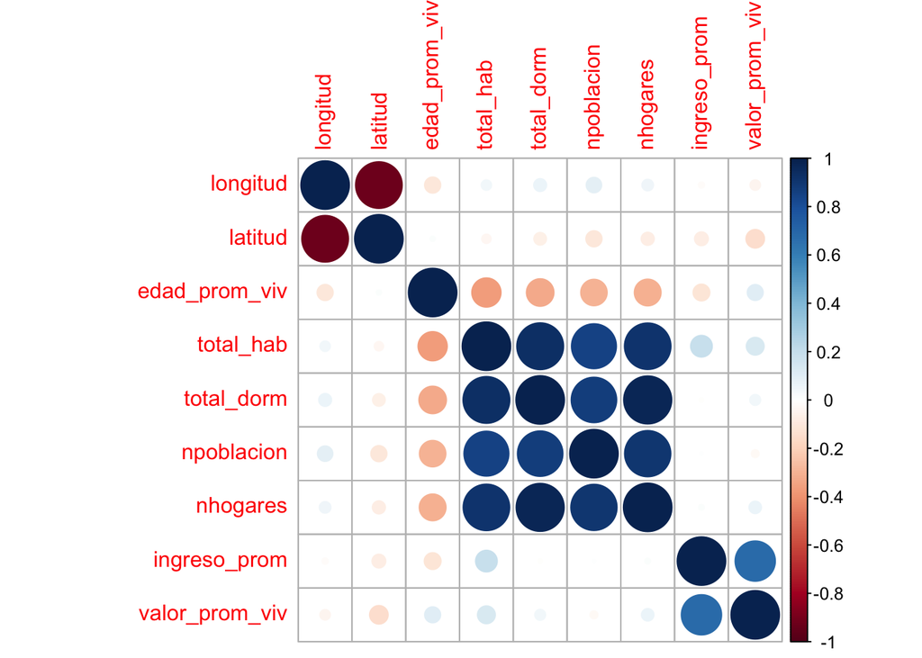

```r
corrplot(cor_viv)
```

### Actividad II

Retomando los datos de las viviendas y usando ggplot:

1. Realice un histograma del valor promedio de las viviendas

Generamos un elemento `ggplot` llamado `g`, en donde colocamos que usaremos la variable `valor_prom_viv` para graficar en el eje x.

```r
g <- ggplot(data = viv, aes(x = valor_prom_viv))
```

Luego añadimos la indicaicón de graficar un histograma y añadimos un título:

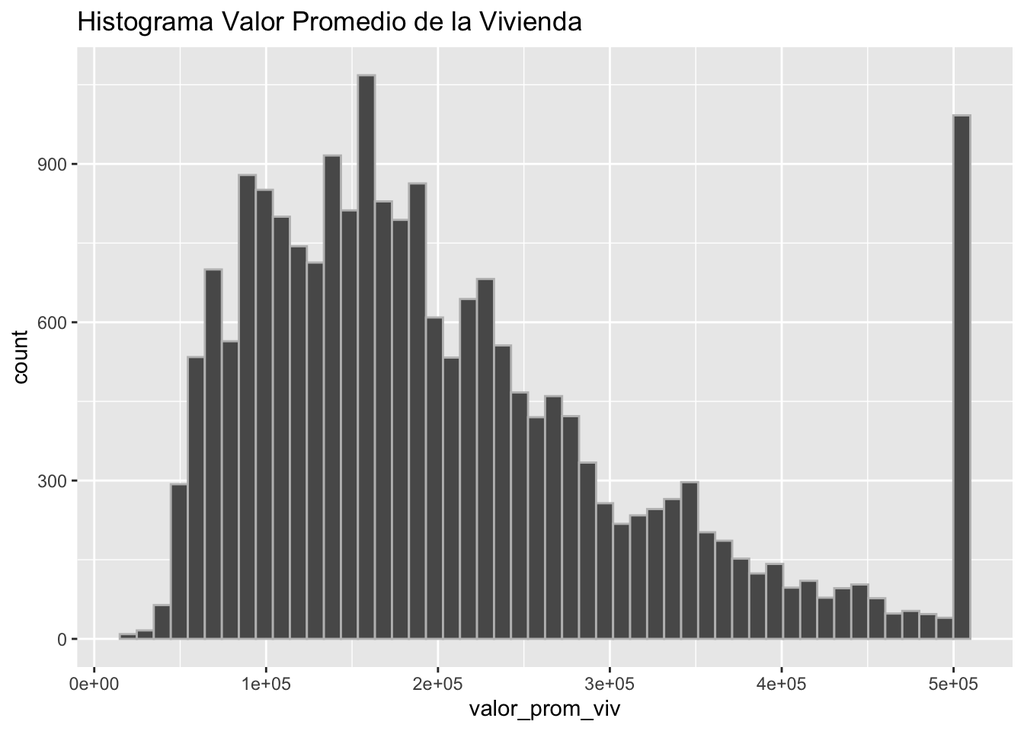

```r
g + geom_histogram(col = "grey", bins = 50) +
  ggtitle("Histograma Valor Promedio de la Vivienda")
```

2. Realice un boxplot del promedio de las viviendas según proximidad al océano

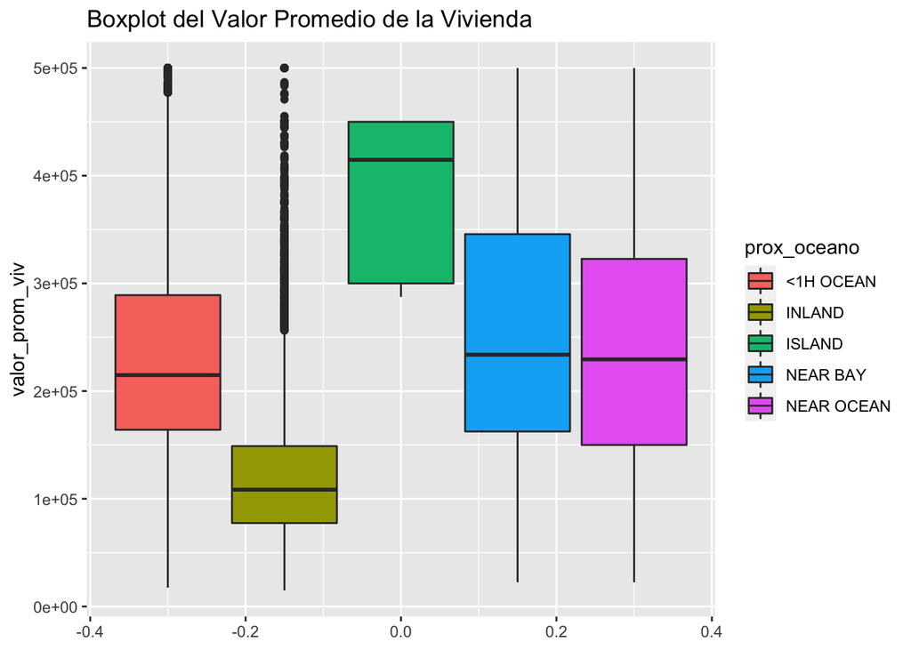

```r
ggplot(data = viv, aes(x = valor_prom_viv, fill = prox_oceano)) +
  geom_boxplot() +
  coord_flip() +
  ggtitle("Boxplot del Valor Promedio de la Vivienda")
```

3. Realice un gráfico de dispersión entre la longitud y la latitud de las viviendas, matice según el valor de las viviendas para observar el sector donde se concentran las viviendas de menor y mayor valor

En el primer plot los puntos tienen colores con respecto a la variable categórica `prox_oceano`, en donde cada categoría corresponde a un color.

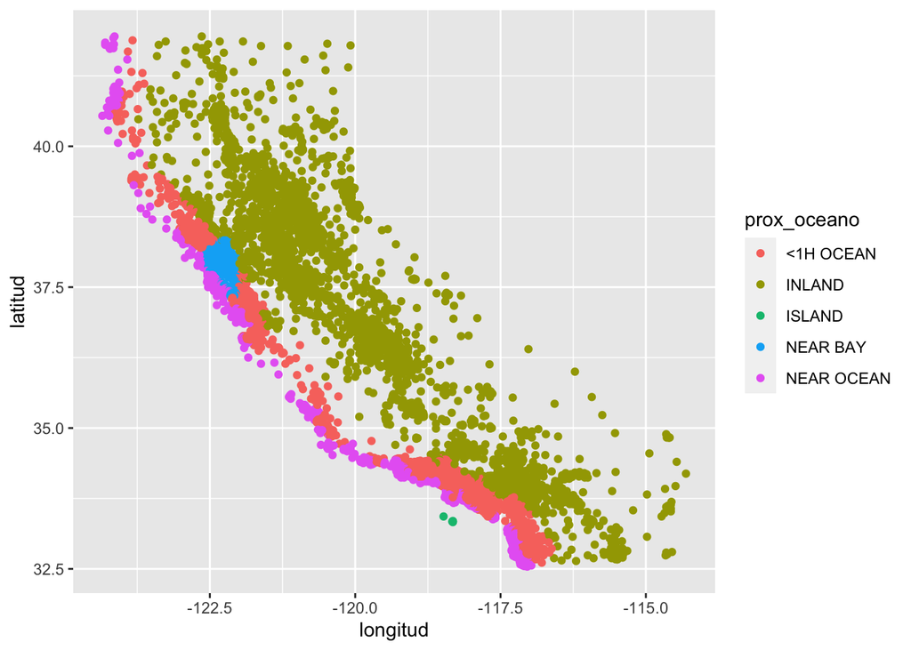

```r
g2 <- ggplot(data = viv, aes(x = longitud, y = latitud,  col = prox_oceano))
g2 + geom_point()
```

En el primer plot los puntos tienen colores con respecto a la variable numérica `valor_prom_viv`, en donde a cada punto se le asigna un color correspondiente a una grilla de colores dependiendo del valor de esta variable.

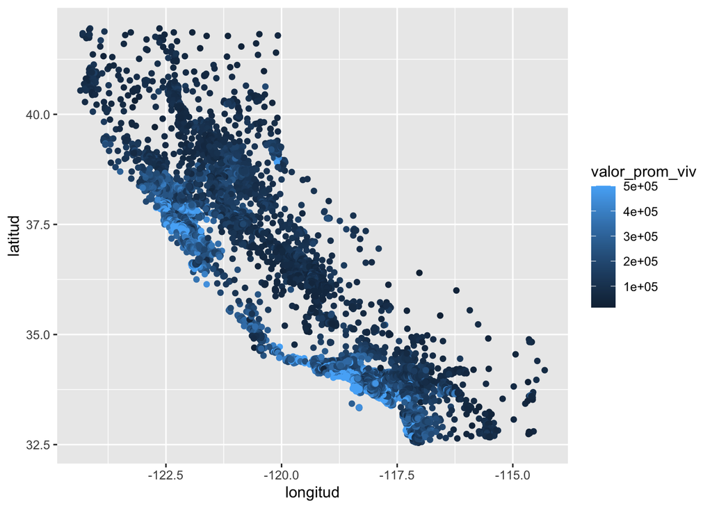

```r
g3 <- ggplot(data = viv, aes(x = longitud, y = latitud,  col = valor_prom_viv))
g3 + geom_point()
```

Notar que los precios de las viviendas están muy relacionados con la ubicación, aquellas viviendas más cercanas al Oceano tienen mayor valor en promedio, al igual que aquellas que se encuentran en determinado sector al norte de la ciudad.

4. Realice un análisis de las correlaciones entre las variables

```r
library(ggcorrplot)
```

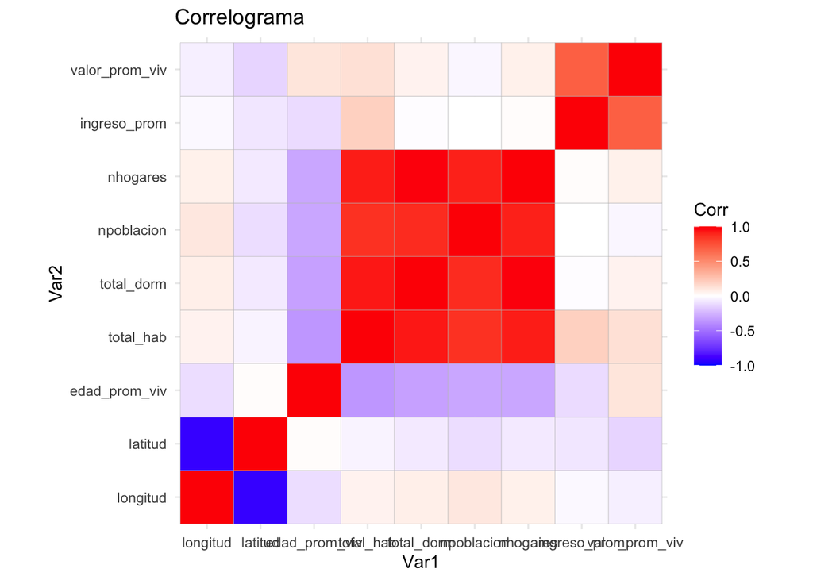

```r
ggcorrplot(cor_viv) +
ggtitle("Correlograma") +
theme_minimal()
```

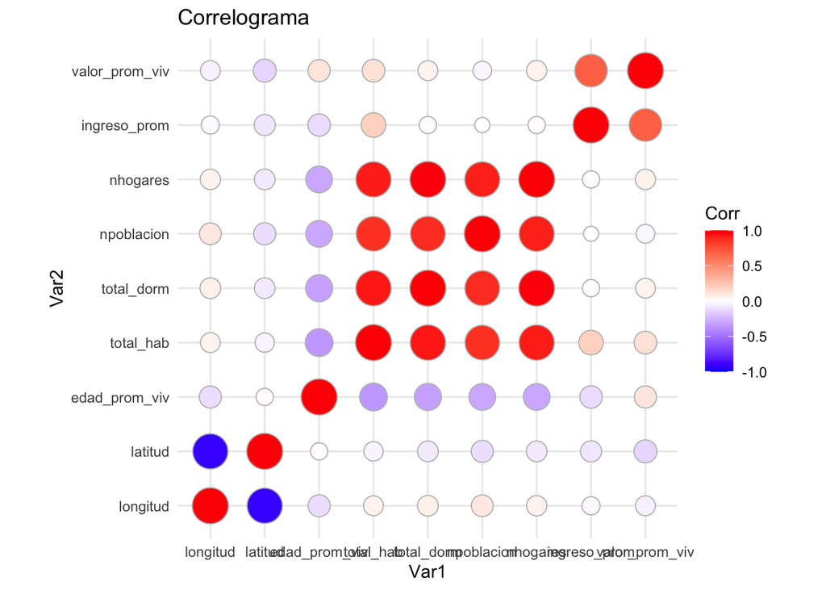

```r
ggcorrplot(cor_viv, method = 'circle')+
ggtitle("Correlograma")  +
theme_minimal()
```

5. Realice un análisis de la dispersión entre las variables

Usamos el comando `ggpais` de la librería `GGally` para realizar un gráfico de todos los pares de variables y su correlación respectiva.

```r
library(GGally)
```

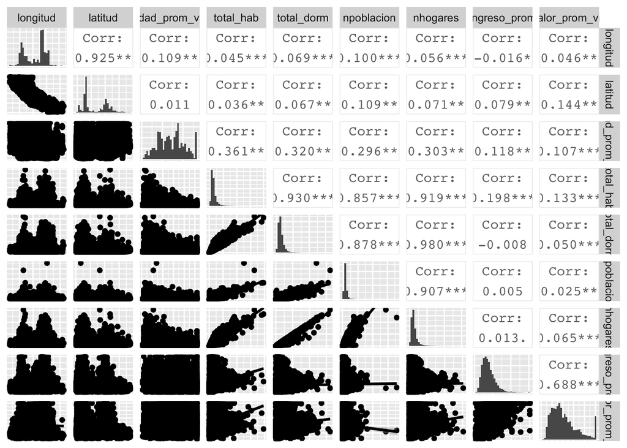

```r
ggpairs(viv_cont,
lower = list(continuous = "smooth"),
diag = list(continuous = "barDiag"),
axisLabels = "none")
```

Notamos claras tendencias lineales entre `nhogares, npoblacion, total_dorm, total_hab` y además entre `longitud y latitud`. En las demás dispersines no podemos discriminar claramente una asociación clara.